# BANA Final Project

Emma Stidd

```r
library(tidyverse)
setwd("~/Downloads")
library(readr)
Churn_Modeling <- read_csv("Churn Modeling.csv")
```

Question 1: Does the person’s age have a correlation to the balance in their account conditional to male and female?

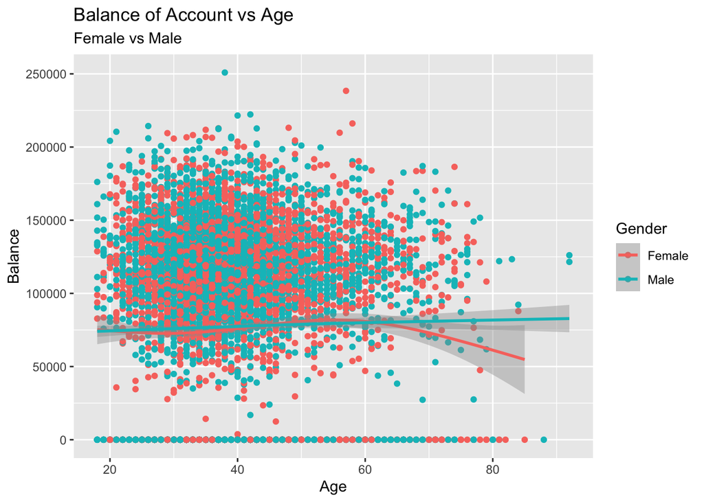

```r
ggplot(data = Churn_Modeling, aes(x = Age, y = Balance, color = Gender))+
geom_point()+
geom_smooth()+
labs(title = "Balance of Account vs Age", subtitle = "Female vs Male", x = "Age", y = "Balance")
```

From the scatterplot and smooth line that was created, there does not seem to be a correlation to age and balance in accounts. This was surprising because generally you think the older a person gets the more money they would have. However with investments I think it is a little different and explains why there isn’t a visual correlation.

Question 2: Is there a relationship between region and balance in account conditional to whether the customer churned or not?

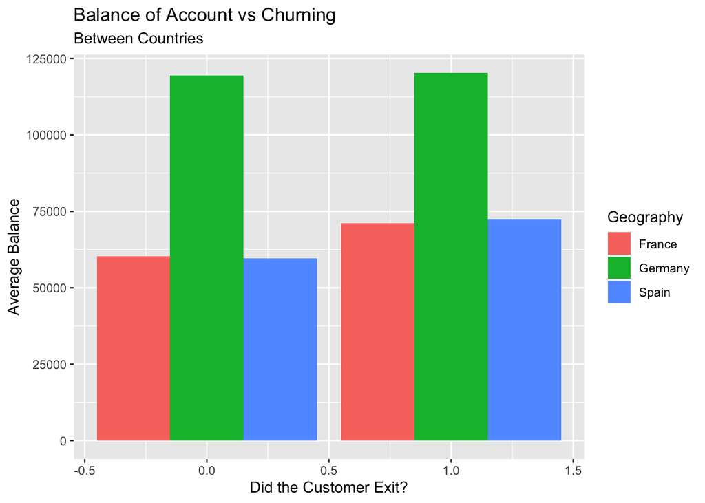

```r
ggplot(data = Churn_Modeling, aes(x = Exited, y = Balance, fill = Geography))+
geom_bar(position = "dodge", stat = "summary", fun = "mean")+
labs(title = "Balance of Account vs Churning", subtitle = "Between Countries", x = "Did the Customer Exit?", y = "Average Balance")
```

In this analysis, it appears that if a customer churns, the balance in their account may be a small amount higher than a customer who decides not to churn. In the graph, the left side indicates the customers who did not churn in France, Germany, and Spain. On the right it is customers who did churn in those countries. In every country, the right side is a little bit higher. In Germany the average account balance is almost double that in France and Spain. This could be because Germany is a wealthier country than the other 2.